# Прогнозирование оттока клиентов

### Анализ портрета клиента

Построим таблицу, которая опишет типичного пользователя, который чаще всего встречается среди ушедших из компании.

```python
def customer_profile_analysis(dataset, target):
    # Разделение данных на две группы: отток и не отток
    churn = dataset[dataset[target] == 'Yes']
    no_churn = dataset[dataset[target] == 'No']

    summary = {}

    for column in dataset.columns:
        if column == target:
            continue

        if dataset[column].dtype in [np.float64, np.int64]:
            churn_stat = churn[column].mean()
            no_churn_stat = no_churn[column].mean()
            relative_difference = (churn_stat - no_churn_stat) / no_churn_stat
        else:
            churn_stat = churn[column].mode()[0]
            no_churn_stat = no_churn[column].mode()[0]
            # Не применимо для категориальных признаков
            relative_difference = 'N/A'

        summary[column] = {
            'Отток': churn_stat,
            'Не отток': no_churn_stat,
            'Относительная разница': relative_difference
        }

    summary_df = pd.DataFrame(summary).T
    return summary_df
```

```python
display(customer_profile_analysis(
    full_data.drop(['begin_date', 'end_date'], axis=1),
    'broken_contract'
))
```

|  | Отток | Не отток | Относительная разница |
| --- | --- | --- | --- |
| contract_duration | 924.86376 | 893.534692 | 0.035062 |
| paperless_billing | Yes | Yes | N/A |
| payment_method | Electronic check | Electronic check | N/A |
| type | Month-to-month | Month-to-month | N/A |
| monthly_charges | 75.546004 | 62.775514 | 0.203431 |
| total_charges | 2371.377275 | 2067.561783 | 0.146944 |
| gender | Male | Male | N/A |
| senior_citizen | 0 | 0 | N/A |
| partner | Yes | No | N/A |
| dependents | No | No | N/A |
| service_kind | Internet and phone | Internet and phone | N/A |
| additional_services | 3.443233 | 2.277703 | 0.511713 |
| internet_service | Fiber optic | Fiber optic | N/A |
| online_security | No | No | N/A |
| online_backup | Yes | No | N/A |
| device_protection | Yes | No | N/A |
| tech_support | No | No | N/A |
| streaming_tv | Yes | No | N/A |
| streaming_movies | Yes | No | N/A |
| multiple_lines | Yes | No | N/A |

Типичный клиент, разорвавший контракт, во многом похож на типичного клиента, который продолжает использовать услуги компании. Его портрет выглядит так:

- длительность контракта - 924 дня (2.5 года);
- ежемесячный платеж - 75.5 у.е.;
- общие расходы - 2371 у.е.;
- получает расчётный лист электронно;
- платеж осуществялется ежемесячно электронным чеком;
- чаще это молодой мужчина
- имеет супруга, но без детей;
- пользуется услугами и интернета, и телефонии, подключение идет через оптоволокно;
- также у него имеется в среднем 3 подключенных доп. услуг.

Далее рассмотрим какую долю составляют ушедшие клиенты по каждому уникальному значению у категориальных признаков.

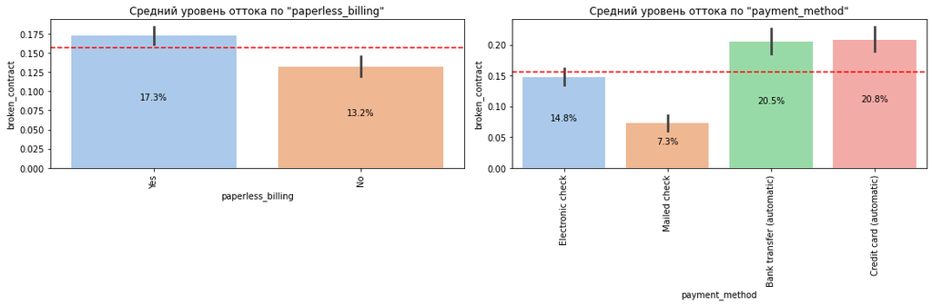

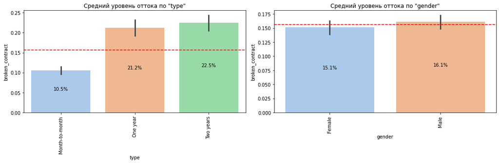

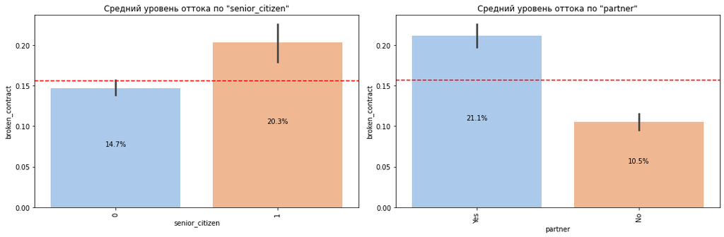

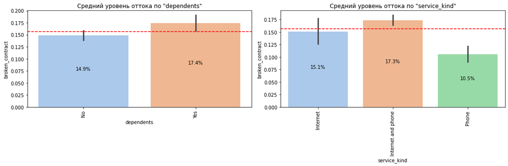

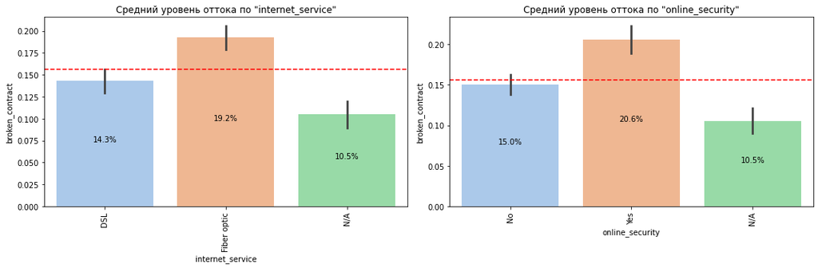

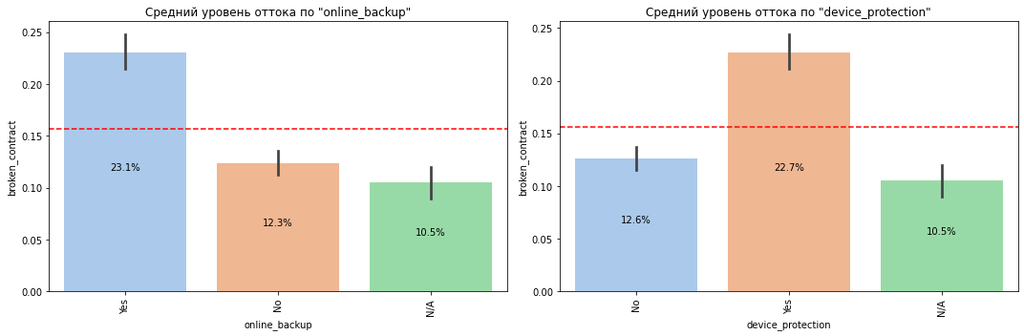

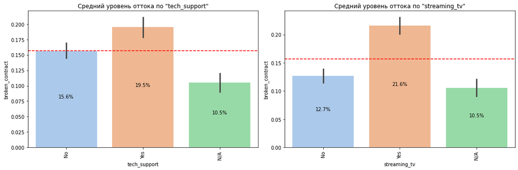

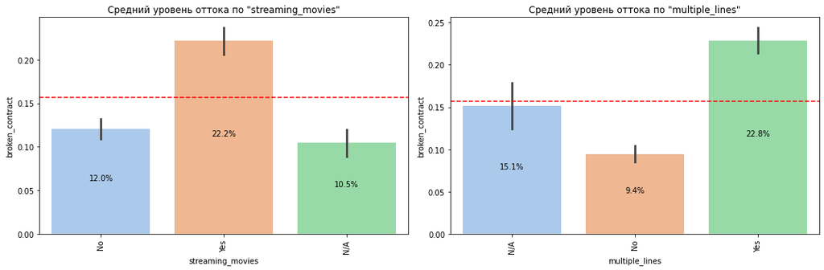

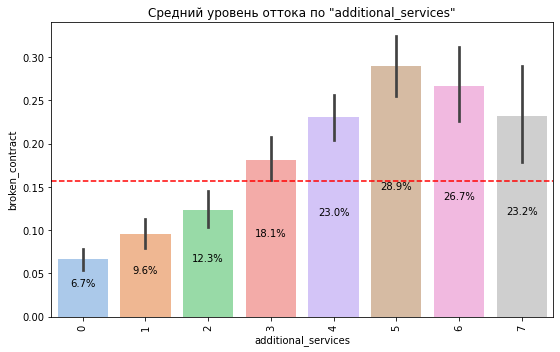

```python
columns = cat_col(full_data)[1:].tolist()
columns.append('additional_services')
stacked_plot(full_data, columns, 'broken_contract')
```

Мы видим следующее:

- Незначительная разница присутствует по расчётным листам - клиенты, получающие электронный расчётный лист, уходят на 4.1% чаще.
- По способу оплаты мы видим, что у автоплатежей при помощи банковского перевода или кредитной карты доля ушедших клиентов значительно больше и превышает 20%. Клиенты, осуществляющие оплату чеком по почте уходят лишь в 7.3% случаев.
- Клиенты, оплачивающие услуги один или два раза в год уходят гораздо чаще - более, чем в 21.2—22.5% случаев. Из тех, кто вносит оплату ежемесячно, лишь 10.5% клиентов разрывают контракт.
- По полу разницы практически нет - среди мужчин ушедших клиентов на 1% больше.
- Пенсионеры разорвали контракт в 20.3% случаев. Более молодые клиенты разрывают контракт на 5.6% реже.
- Клиенты, имеющие супруга, уходят в два раза чаще - их доля составляет 21.1%.
- Разница между клиентами с детьми и без незначительна - ушедших клиентов с детьми на 2.5% больше.
- Клиенты, подключившие интернет и телефонию одновременно, уходят чаще всего (17.3%). Реже всего уходят те, кто пользуется только телефоном - их доля составляет лишь 10.5%.
- Клиенты, использующие оптоволокно, уходят на 4.9% чаще.
- Среди людей, подключивших ту или иную доп. услугу, доля ушедших клиентов составляет 19.5—23.1%, что заменто больше тех, кто не подключал доступные им доп. услуги (9.4—15.6%).
- На последнем графике мы более подробно видим, что больше всего ушедших клиентов приходится на тех, кто подключал 5—6 доп. услуг одновременно - больше четверти (26.7—28.9%).

В итоге мы видим клиентов с какими параметрами имеют самый высокий риск оттока. Их портрет выглядит так:

- длительность контракта - 915 дней (2.5 лет);
- ежемесячный платеж - 84.2 у.е.;
- общие расходы - 2139 у.е.;
- получает расчётный лист электронно;
- платеж осуществялется автоплатежом при помощи кредитной карты или банковским переводом;
- оплата услуг происходит один-два раза в год;
- являются мужчинами пенисионного возраста;
- имеют супруга и детей;
- подключен и интернет, и телефония, для подключения интеренета используется оптоволокно;
- имеют от 3 до 7 подключенных доп. услуг.

### Корреляционный анализ

#### Матрица корреляции

Перед тем, как построить матрицу корреляции, удалим признаки с датами из датафрейма. Они нам не нужны, т.к. мы не решаем задачу временных рядов.

```python
full_data = full_data.drop(['begin_date', 'end_date'], axis=1)
```

Изучим общие взаимосвязи между признаками.

```python
display(HTML('<h3>Матрица корреляции признаков</h3>'))
display(
    full_data[full_data.columns].phik_matrix(
        interval_cols=num_col(full_data)[:-1]
    ).style.background_gradient('cividis')
)
```

Матрица корреляции признаков

|  | contract_duration | broken_contract | paperless_billing | payment_method | type | monthly_charges | total_charges | gender | senior_citizen | partner | dependents | service_kind | additional_services | internet_service | online_security | online_backup | device_protection | tech_support | streaming_tv | streaming_movies | multiple_lines |
| --- | --- | --- | --- | --- | --- | --- | --- | --- | --- | --- | --- | --- | --- | --- | --- | --- | --- | --- | --- | --- | --- |
| contract_duration | 1.000000 | 0.374361 | 0.025643 | 0.350860 | 0.633814 | 0.386862 | 0.848304 | 0.000000 | 0.063165 | 0.452940 | 0.198278 | 0.040977 | 0.427183 | 0.060400 | 0.346201 | 0.366058 | 0.374602 | 0.353258 | 0.306524 | 0.307153 | 0.346654 |
| broken_contract | 0.374361 | 1.000000 | 0.083159 | 0.214624 | 0.094073 | 0.225959 | 0.302751 | 0.009029 | 0.085995 | 0.226776 | 0.046841 | 0.044915 | 0.285215 | 0.056527 | 0.058587 | 0.089683 | 0.085582 | 0.051437 | 0.078503 | 0.086546 | 0.105152 |
| paperless_billing | 0.025643 | 0.083159 | 1.000000 | 0.369684 | 0.107076 | 0.467018 | 0.201023 | 0.000000 | 0.241965 | 0.013973 | 0.173503 | 0.199994 | 0.341894 | 0.231074 | 0.207967 | 0.194901 | 0.195274 | 0.200237 | 0.204304 | 0.201824 | 0.099860 |
| payment_method | 0.350860 | 0.214624 | 0.369684 | 1.000000 | 0.277436 | 0.398906 | 0.335398 | 0.000000 | 0.292447 | 0.242734 | 0.225051 | 0.273125 | 0.462245 | 0.323494 | 0.315245 | 0.292835 | 0.297348 | 0.317163 | 0.283987 | 0.284979 | 0.174813 |
| type | 0.633814 | 0.094073 | 0.107076 | 0.277436 | 1.000000 | 0.388089 | 0.470487 | 0.000000 | 0.086227 | 0.179447 | 0.147569 | 0.449646 | 0.455966 | 0.505769 | 0.637001 | 0.581839 | 0.631674 | 0.671733 | 0.549790 | 0.553779 | 0.243135 |
| monthly_charges | 0.386862 | 0.225959 | 0.467018 | 0.398906 | 0.388089 | 1.000000 | 0.710666 | 0.011139 | 0.304566 | 0.202848 | 0.185006 | 0.889343 | 0.781331 | 0.918958 | 0.812555 | 0.818792 | 0.827254 | 0.816521 | 0.864601 | 0.863600 | 0.710072 |
| total_charges | 0.848304 | 0.302751 | 0.201023 | 0.335398 | 0.470487 | 0.710666 | 1.000000 | 0.000000 | 0.135556 | 0.381439 | 0.083553 | 0.474527 | 0.621259 | 0.489766 | 0.516243 | 0.550290 | 0.558149 | 0.527539 | 0.555088 | 0.553798 | 0.467550 |
| gender | 0.000000 | 0.009029 | 0.000000 | 0.000000 | 0.000000 | 0.011139 | 0.000000 | 1.000000 | 0.000000 | 0.000000 | 0.000000 | 0.000000 | 0.000000 | 0.000000 | 0.001951 | 0.000000 | 0.000000 | 0.000000 | 0.000000 | 0.000000 | 0.000000 |
| senior_citizen | 0.063165 | 0.085995 | 0.241965 | 0.292447 | 0.086227 | 0.304566 | 0.135556 | 0.000000 | 1.000000 | 0.017018 | 0.324714 | 0.112610 | 0.181103 | 0.160675 | 0.127201 | 0.109890 | 0.110070 | 0.135167 | 0.111622 | 0.113693 | 0.087972 |
| partner | 0.452940 | 0.226776 | 0.013973 | 0.242734 | 0.179447 | 0.202848 | 0.381439 | 0.000000 | 0.017018 | 1.000000 | 0.652047 | 0.003508 | 0.303385 | 0.000000 | 0.091110 | 0.091936 | 0.100019 | 0.076228 | 0.082180 | 0.077434 | 0.085937 |
| dependents | 0.198278 | 0.046841 | 0.173503 | 0.225051 | 0.147569 | 0.185006 | 0.083553 | 0.000000 | 0.324714 | 0.652047 | 1.000000 | 0.085730 | 0.121978 | 0.108940 | 0.117447 | 0.098101 | 0.094952 | 0.110011 | 0.088606 | 0.085140 | 0.011466 |
| service_kind | 0.040977 | 0.044915 | 0.199994 | 0.273125 | 0.449646 | 0.889343 | 0.474527 | 0.000000 | 0.112610 | 0.003508 | 0.085730 | 1.000000 | 0.638005 | 0.964439 | 0.943017 | 0.942841 | 0.942817 | 0.943053 | 0.943229 | 0.943079 | 0.952656 |
| additional_services | 0.427183 | 0.285215 | 0.341894 | 0.462245 | 0.455966 | 0.781331 | 0.621259 | 0.000000 | 0.181103 | 0.303385 | 0.121978 | 0.638005 | 1.000000 | 0.633926 | 0.697497 | 0.710544 | 0.739073 | 0.720673 | 0.733912 | 0.734720 | 0.559128 |
| internet_service | 0.060400 | 0.056527 | 0.231074 | 0.323494 | 0.505769 | 0.918958 | 0.489766 | 0.000000 | 0.160675 | 0.000000 | 0.108940 | 0.964439 | 0.633926 | 1.000000 | 0.949513 | 0.942843 | 0.942812 | 0.948928 | 0.946707 | 0.946288 | 0.739759 |
| online_security | 0.346201 | 0.058587 | 0.207967 | 0.315245 | 0.637001 | 0.812555 | 0.516243 | 0.001951 | 0.127201 | 0.091110 | 0.117447 | 0.943017 | 0.697497 | 0.949513 | 1.000000 | 0.947213 | 0.946777 | 0.952636 | 0.943079 | 0.943245 | 0.540177 |
| online_backup | 0.366058 | 0.089683 | 0.194901 | 0.292835 | 0.581839 | 0.818792 | 0.550290 | 0.000000 | 0.109890 | 0.091936 | 0.098101 | 0.942841 | 0.710544 | 0.942843 | 0.947213 | 1.000000 | 0.947477 | 0.947745 | 0.945782 | 0.945388 | 0.562821 |
| device_protection | 0.374602 | 0.085582 | 0.195274 | 0.297348 | 0.631674 | 0.827254 | 0.558149 | 0.000000 | 0.110070 | 0.100019 | 0.094952 | 0.942817 | 0.739073 | 0.942812 | 0.946777 | 0.947477 | 1.000000 | 0.950235 | 0.952853 | 0.953706 | 0.564502 |
| tech_support | 0.353258 | 0.051437 | 0.200237 | 0.317163 | 0.671733 | 0.816521 | 0.527539 | 0.000000 | 0.135167 | 0.076228 | 0.110011 | 0.943053 | 0.720673 | 0.948928 | 0.952636 | 0.947745 | 0.950235 | 1.000000 | 0.946385 | 0.946408 | 0.541003 |
| streaming_tv | 0.306524 | 0.078503 | 0.204304 | 0.283987 | 0.549790 | 0.864601 | 0.555088 | 0.000000 | 0.111622 | 0.082180 | 0.088606 | 0.943229 | 0.733912 | 0.946707 | 0.943079 | 0.945782 | 0.952853 | 0.946385 | 1.000000 | 0.965297 | 0.585944 |
| streaming_movies | 0.307153 | 0.086546 | 0.201824 | 0.284979 | 0.553779 | 0.863600 | 0.553798 | 0.000000 | 0.113693 | 0.077434 | 0.085140 | 0.943079 | 0.734720 | 0.946288 | 0.943245 | 0.945388 | 0.953706 | 0.946408 | 0.965297 | 1.000000 | 0.586713 |
| multiple_lines | 0.346654 | 0.105152 | 0.099860 | 0.174813 | 0.243135 | 0.710072 | 0.467550 | 0.000000 | 0.087972 | 0.085937 | 0.011466 | 0.952656 | 0.559128 | 0.739759 | 0.540177 | 0.562821 | 0.564502 | 0.541003 | 0.585944 | 0.586713 | 1.000000 |

Длительность контракта `'contract_duration'` имеют сильную корреляцию с общими расходами `'total_charges'`, что логично. Ведь чем дольше клиент в компании, тем больше денег в общей сложности он оставляет в компании.

Видео трио признаков, которые все между собой сильно коррелируют - `'monthly_charges'`, `'service_kind'` и `'internet_service'`. Виды используемых услуг влияют, какой тип подключения будет у клиента. Разные типы подключения и используемые услуги, вероятно, вытекают в различия в стоимости услуг. Возможно, один из этих признаков избыточен и его необходимо будет удалить.

Месячные расходы `'monthly_charges'` и все доп. услуги очень сильно коррелируют между собой, т.к. они связаны друг с другом. Это может создать дополнительный шум для моделей, поэтому будет лучше убрать признаки с доп. услугами, оставив взамен сгенерированный нами признак `'additional_services'`.

Наиболее значимую корреляцию с целевым признаком имеют `'contract_duration'`, `'total_charges'`, `'additional_services'`, `'partner'`, `'monthly_charges'` и `'payment_method'`. Корреляция с признаком `'gender'` практически равна 0 - благодаря графикам мы выяснили, что этот признак действительно не имеет никакой связи с уходом клиентов, поэтому его мы можем удалить.

#### Коэффициенты инфляции дисперсии

Проверим признаки на наличие мультиколлинеарности при помощи коэффициента инфляции дисперсии (VIF).

Подготовим данные для расчета коэффициента.

```python
train_data, test_data = train_test_split(
    full_data,
    test_size=0.25,
    random_state=RS
)

categories = [
    ['Month-to-month', 'One year', 'Two years'],  # Для 'type'
    ['N/A', 'No', 'Yes'],  # Для остальных признаков
    ['N/A', 'No', 'Yes'],
    ['N/A', 'No', 'Yes'],
    ['N/A', 'No', 'Yes'],
    ['N/A', 'No', 'Yes'],
    ['N/A', 'No', 'Yes'],
    ['N/A', 'No', 'Yes']
]

ord_cols = ['type', 'online_security', 'online_backup',
            'device_protection', 'tech_support', 'streaming_tv',
            'streaming_movies', 'multiple_lines']
ohe_cols = ['broken_contract', 'paperless_billing', 'payment_method',
            'gender', 'senior_citizen', 'partner', 'dependents',
            'service_kind', 'internet_service']

# Создание пайплайна для подготовки данных
vif_preprocessor = ColumnTransformer(
    transformers=[
        ('ord', OrdinalEncoder(
            categories=categories,
            handle_unknown='use_encoded_value',
            unknown_value=-1
        ), ord_cols),
        ('ohe', OneHotEncoder(
            drop='first',
            handle_unknown = 'ignore',
            sparse_output=False
        ), ohe_cols)
    ])

# Применение пайплайна к тренировочным данным
train_data_vif = vif_preprocessor.fit_transform(train_data)
train_data_vif = pd.DataFrame(
    train_data_vif,
    columns= ord_cols + list(
        vif_preprocessor.named_transformers_['ohe'].get_feature_names_out(
            ohe_cols
        )
    )
)
```

```python
vif(train_data_vif)
```

Коэффициент инфляции дисперсии (VIF)

|  | feature | VIF |
| --- | --- | --- |
| 20 | internet_service_N/A | inf |
| 18 | service_kind_Phone | inf |
| 17 | service_kind_Internet and phone | 15.530696 |
| 6 | streaming_movies | 12.730909 |
| 5 | streaming_tv | 12.709051 |
| 7 | multiple_lines | 11.881436 |
| 3 | device_protection | 11.104181 |
| 4 | tech_support | 10.889304 |
| 1 | online_security | 9.684401 |
| 2 | online_backup | 9.675202 |
| 19 | internet_service_Fiber optic | 3.557177 |
| 9 | paperless_billing_Yes | 2.910549 |
| 0 | type | 2.861656 |
| 15 | partner_Yes | 2.774397 |
| 11 | payment_method_Electronic check | 2.646028 |
| 12 | payment_method_Mailed check | 2.140530 |
| 16 | dependents_Yes | 1.988898 |
| 13 | gender_Male | 1.956466 |
| 10 | payment_method_Credit card (automatic) | 1.906933 |
| 14 | senior_citizen_1 | 1.364433 |
| 8 | broken_contract_Yes | 1.280730 |

`'service_kind_Phone'` и `'internet_service_N/A'` показывают полную мультиколлинеарность между собой - один из признаков полностью объясняется другим. Это логично, т.к. все клиенты, пользующиеся только телефоном, в типе подключения имеют значение 'N/A'. Удалим один из них.

```python
vif(train_data_vif.drop([
    'service_kind_Phone'
], axis=1))
```

Коэффициент инфляции дисперсии (VIF)

|  | feature | VIF |
| --- | --- | --- |
| 17 | service_kind_Internet and phone | 15.530696 |
| 6 | streaming_movies | 12.730909 |
| 5 | streaming_tv | 12.709051 |
| 7 | multiple_lines | 11.881436 |
| 3 | device_protection | 11.104181 |
| 4 | tech_support | 10.889304 |
| 1 | online_security | 9.684401 |
| 2 | online_backup | 9.675202 |
| 19 | internet_service_N/A | 4.869514 |
| 18 | internet_service_Fiber optic | 3.557177 |
| 9 | paperless_billing_Yes | 2.910549 |
| 0 | type | 2.861656 |
| 15 | partner_Yes | 2.774397 |
| 11 | payment_method_Electronic check | 2.646028 |
| 12 | payment_method_Mailed check | 2.140530 |
| 16 | dependents_Yes | 1.988898 |
| 13 | gender_Male | 1.956466 |
| 10 | payment_method_Credit card (automatic) | 1.906933 |
| 14 | senior_citizen_1 | 1.364433 |
| 8 | broken_contract_Yes | 1.280730 |

Высокие значения VIF наблюдаются по всем признакам с доп. услугами, а также созданный нами `'service_kind'`. Попробуем убрать доп. услуги и проверить, что изменится.

```python
vif(train_data_vif.drop([
    'online_security',
    'online_backup',
    'device_protection',
    'tech_support',
    'streaming_tv',
    'streaming_movies',
    'multiple_lines',
    'service_kind_Phone'
], axis=1))
```

Коэффициент инфляции дисперсии (VIF)

|  | feature | VIF |
| --- | --- | --- |
| 10 | service_kind_Internet and phone | 5.959593 |
| 11 | internet_service_Fiber optic | 3.207924 |
| 8 | partner_Yes | 2.703109 |
| 2 | paperless_billing_Yes | 2.669647 |
| 4 | payment_method_Electronic check | 2.340493 |
| 12 | internet_service_N/A | 2.227396 |
| 0 | type | 2.198539 |
| 9 | dependents_Yes | 1.974889 |
| 6 | gender_Male | 1.895581 |
| 5 | payment_method_Mailed check | 1.874235 |
| 3 | payment_method_Credit card (automatic) | 1.743535 |
| 7 | senior_citizen_1 | 1.344912 |
| 1 | broken_contract_Yes | 1.257511 |

`'service_kind'` снова показывает высокое значение VIF. Добавленный нами признак показывает мультиколлинеарность с другими, поэтому его лучше будет убрать.

```python
vif(train_data_vif.drop([
    'online_security',
    'online_backup',
    'device_protection',
    'tech_support',
    'streaming_tv',
    'streaming_movies',
    'multiple_lines',
    'service_kind_Phone',
    'service_kind_Internet and phone'
], axis=1))
```

Коэффициент инфляции дисперсии (VIF)

|  | feature | VIF |
| --- | --- | --- |
| 8 | partner_Yes | 2.673702 |
| 2 | paperless_billing_Yes | 2.506232 |
| 10 | internet_service_Fiber optic | 2.389387 |
| 4 | payment_method_Electronic check | 2.092868 |
| 0 | type | 2.091463 |
| 9 | dependents_Yes | 1.966943 |
| 6 | gender_Male | 1.834815 |
| 11 | internet_service_N/A | 1.670776 |
| 5 | payment_method_Mailed check | 1.623521 |
| 3 | payment_method_Credit card (automatic) | 1.608321 |
| 7 | senior_citizen_1 | 1.344064 |
| 1 | broken_contract_Yes | 1.256520 |

На наличие мультиколлинеарности указывают значения выше 5, но теперь у нас показатели VIF не превышают 2.7.

#### Диаграмма рассеяния

Далее изучим связи числовых признаков друг с другом, построив диаграммы рассеяния.

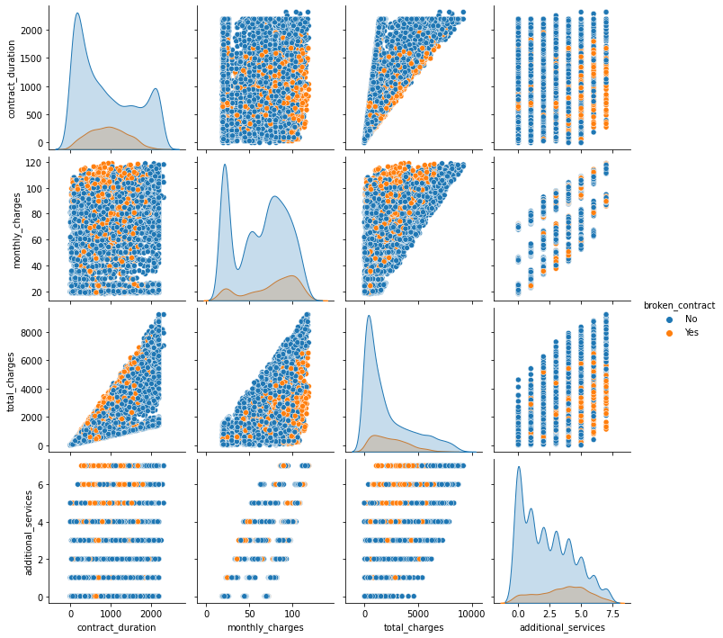

```python
sns.pairplot(full_data.drop('senior_citizen', axis=1), hue='broken_contract');
```

Положительная линейная корреляция имеется у `'total_charges'` с `'contract_duration'` и `'monthly_charges'`.

Также мы можем увидеть заметную положительную линейную связь у `'additional_services'` с `'monthly_charges'` и более слабую с `'total_charges'`.

### Вывод

Целевой признак сильно не сбалансирован - мы имеем 15.6% клиентов, разорвавших договор. Но балансировать классы нам не требуется, т.к. для оценки модели мы используем метрику ROC-AUC, которая нечиствительна к дисбалансу.

Более двух трети клиентов одновременно используют интернет и телефонию, и именно среди них больше всего ушедших клиентов (17.3%). Мы наблюдаем тенденцию, что от оператора связи уходят давние клиенты спустя 1.5—3.5 года после заключения договора. Много ушедших приходится на тех, кто оплачивал услуги один или два раза в год, платил за услуги более 80 у.е. в месяц и пользовался бóльшим количеством дополнительных услуг. Среди клиентов, подключивших автоплатеж, в 1.5—2 раза больше ушедших клиентов, чем по другим способам оплаты. Клиенты, имеющие супруга, уходят в два раза чаще.

Признаки, которые будут удалены:

- `'begin_date'`,
- `'end_date'`,
- `'gender'`,
- `'service_kind'`,
- `'online_security'`,
- `'online_backup'`,
- `'device_protection'`,
- `'tech_support'`,
- `'streaming_tv'`,
- `'streaming_movies'`,
- `'multiple_lines'`

Перед обучением модели мы удалим признаки с датами заключения и расторжения контракта - высокая корреляция с длительностью контракта и целевым признаком делает их избыточными и потенциально вызывающими утечку целевого признака.

Также мы удалим признаки с дополнительными услугами, т.к. они сильно коррелируют между собой и с месячными расходами, создавая дополнительный шум для модели. Поэтому вместо них оставлен агрегированный признак `'additional_services'`.

Между полом клиента и целевым признаком практически нулевая корреляция, у этого признака нет значимой связи с оттоком клиентов.

Вернуться к содержанию

## Обучение моделей машинного обучения

### Подготовка данных

Делим признаки на входные и целевой.

```python
X = full_data.drop([
    'broken_contract',
    'gender',
    'service_kind',
    'online_security',
    'online_backup',
    'device_protection',
    'tech_support',
    'streaming_tv',
    'streaming_movies',
    'multiple_lines'
], axis=1)

y = full_data['broken_contract']
```

Разделяем категориальные и количественные признаки.

```python
cat_columns = cat_col(X)
num_columns = num_col(X)
```

Разбиваем признаки на тренировочную и тестовую выборки в соотношении 3:1.

```python
X_train, X_test, y_train, y_test = train_test_split(
    X,
    y,
    test_size=0.25,
    stratify=y,
    random_state=RS
)
```

Проверим корректность разделения получившихся выборок.

```python
for sample_name in ['X_train', 'X_test',
                   'y_train', 'y_test']:

    sample = eval(sample_name)
    print(f'Размер выборки {sample_name}: {sample.shape} '
          f'({round(sample.shape[0] / full_data.shape[0] * 100)}%)')
```

```
Размер выборки X_train: (5279, 11) (75%)
Размер выборки X_test: (1760, 11) (25%)
Размер выборки y_train: (5279,) (75%)
Размер выборки y_test: (1760,) (25%)
```

Кодируем целевой признак при помощи `LabelEncoder`.

```python
le = LabelEncoder()
y_train = le.fit_transform(y_train)
y_test = le.transform(y_test)
```

Также подготовим два препроцессора для разных моделей:

- для линейной модели мы используем `StandardScaler` для масштабирования и `OneHotEncoder` для кодирования,
- для остальных моделей мы используем `OrdinalEncoder` для кодирования.

```python
lr_preprocessor = ColumnTransformer(
    transformers=[

        ('num', StandardScaler(), num_columns),

        ('cat',
         OneHotEncoder(
             drop='first',
             handle_unknown = 'ignore',
             sparse_output=False
         ), cat_columns)

    ], remainder='passthrough')
```

```python
preprocessor = ColumnTransformer(
    transformers=[(
        'cat',
        OrdinalEncoder(
            handle_unknown='use_encoded_value',
            unknown_value=-1
        ), cat_columns
    )],
    remainder='passthrough'
)
```

### Обучение моделей

Обучим несколько моделей:

- `LogisticRegression`,
- `RandomForestClassifier`,
- `CatBoostClassifier`.

Для каждой модели попробуем подобрать разные гиперпараметры.

```python
models = [
    {
        'model_pipeline': Pipeline(steps=[
            ('preprocessor', lr_preprocessor),
            ('model', LogisticRegression(
                random_state=RS,
                max_iter=1000
            ))
        ]),
        'param_grid': {
            'model__C': [0.1, 1.0, 10.0],
            'model__solver': ['lbfgs', 'liblinear']
        },
        'name': 'LogisticRegression'
    },
{
        'model_pipeline': Pipeline(steps=[
            ('preprocessor', preprocessor),
            ('model', RandomForestClassifier(random_state=RS))
        ]),
        'param_grid': {
            'model__n_estimators': [10, 100, 300],
            'model__max_depth': [10, 20, 30]
        },
        'name': 'RandomForestClassifier'
    },
{
        'model_pipeline': Pipeline(steps=[
            ('preprocessor', preprocessor),
            ('model', CatBoostClassifier(
                random_state=RS,
                logging_level='Silent'))
        ]),
        'param_grid': {
            'model__depth': [6, 10],
            'model__learning_rate': [0.01, 0.1]
        },
        'name': 'CatBoostClassifier'
    }
]
```

Создадим таблицу и переменные, в которых мы будем сохранять результаты моделей.

```python
results = pd.DataFrame(
    columns=[
        'Model',
        'Training Time',
        'Prediction Time',
        'ROC-AUC',
        'Accuracy'
    ]
)

best_model = None
best_model_params = None
best_roc_auc = 0
```

Обучаем модели при помощи `GridSearchCV` и сохраняем их метрики, а также сохраняем лучшую модель.

```python
for model in tqdm(models, desc="Total Progress"):
    grid_search = GridSearchCV(
        model['model_pipeline'],
        param_grid=model['param_grid'],
        cv=3,
        scoring=['roc_auc', 'accuracy'],
        refit='roc_auc'
    )

    start_time = time.time()
    grid_search.fit(X_train, y_train)
    training_time = time.time() - start_time

    best_estimator = grid_search.best_estimator_
    best_params = grid_search.best_params_

    start_time = time.time()
    y_pred = best_estimator.predict(X_train)
    prediction_time = time.time() - start_time

    roc_auc = grid_search.cv_results_['mean_test_roc_auc'][
        grid_search.best_index_
    ]
    accuracy = grid_search.cv_results_['mean_test_accuracy'][
        grid_search.best_index_
    ]

    results = results.append({
        'Model': model['name'],
        'Training Time': training_time,
        'Prediction Time': prediction_time,
        'ROC-AUC': roc_auc,
        'Accuracy': accuracy
    }, ignore_index=True)

    if roc_auc > best_roc_auc:
        best_roc_auc = roc_auc
        best_model = best_estimator
        best_model_params = best_params
```

Выводим результаты всех моделей.

```python
# Печать результатов
display(results)
```

|  | Model | Training Time | Prediction Time | ROC-AUC | Accuracy |
| --- | --- | --- | --- | --- | --- |
| 0 | LogisticRegression | 9.035490 | 0.202213 | 0.763149 | 0.861716 |
| 1 | RandomForestClassifier | 24.260562 | 0.189313 | 0.827918 | 0.860011 |
| 2 | CatBoostClassifier | 83.564739 | 0.034686 | 0.899099 | 0.901875 |

Модель `LogisticRegression` показала худшие результаты среди всех моделей. Значения её метрик не соответствует требованиям заказчика.

Модель `RandomForestClassifier` имеет показатели лучше чем у линейной, но она также не достигла порогового значения метрики.

Наилучшие показатели достигла модель `CatBoostClassifier`, она соответствует требованиям заказчика.

Выводим на экран лучшую модель.

```python
print(f'Лучшая модель: {best_model}')
print(f'\nГиперпараметры лучшей модели: {best_model_params}')
```

```
Лучшая модель: Pipeline(steps=[('preprocessor',
                 ColumnTransformer(remainder='passthrough',
                                   transformers=[('cat',
                                                  OrdinalEncoder(handle_unknown='use_encoded_value',
                                                                 unknown_value=-1),
                                                  Index(['paperless_billing', 'payment_method', 'type', 'senior_citizen',
       'partner', 'dependents', 'internet_service'],
      dtype='object'))])),
                ('model',
                 <catboost.core.CatBoostClassifier object at 0x7f31d51112b0>)])

Гиперпараметры лучшей модели: {'model__depth': 6, 'model__learning_rate': 0.1}
```

### Анализ лучшей модели

Проверим лучшую модель на тестовой выборке.

```python
y_pred = best_model.predict(X_test)
y_pred_proba = best_model.predict_proba(X_test)[:, 1]
```

#### ROC-кривая и метрика ROC-AUC

Изучим график ROC-кривой.

```
ROC-AUC лучшей модели на тестовой выборке: 0.92
```

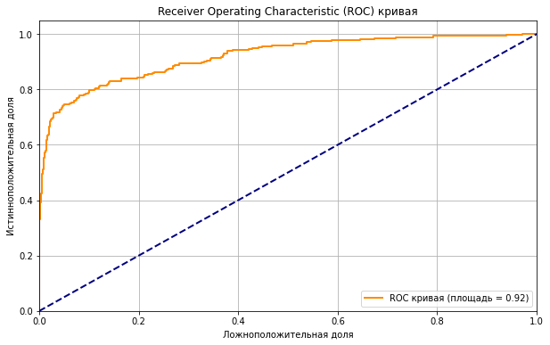

```python
# ROC-AUC
roc_auc = roc_auc_score(y_test, y_pred_proba)
fpr, tpr, _ = roc_curve(y_test, y_pred_proba)
print(f'ROC-AUC лучшей модели на тестовой выборке: {round(roc_auc, 2)}')

plt.figure(figsize=(10, 6))
plt.plot(
    fpr,
    tpr,
    color='darkorange',
    lw=2,
    label=f'ROC кривая (площадь = {roc_auc:.2f})'
)
plt.plot([0, 1], [0, 1], color='navy', lw=2, linestyle='--')
plt.xlim([0.0, 1.0])
plt.ylim([0.0, 1.05])
plt.xlabel('Ложноположительная доля')
plt.ylabel('Истинноположительная доля')
plt.title('Receiver Operating Characteristic (ROC) кривая')
plt.legend(loc='lower right')
plt.grid()
plt.show()
```

На тестовой выборке значение ROC-AUC выше. Значение метрики 0.92 свидетельствует о высокой точности модели.

На графике кривая очень сильно выпирает над диагональю случайного классификатора - это указывает на хорошее качество модели.

#### Матрица ошибок и метрика Accuracy

Рассмотрим матрицу ошибок лучшей модели.

```
Accuracy лучшей модели на тестовой выборке: 0.93
```

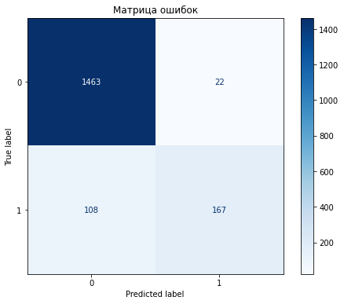

```python
print(f'Accuracy лучшей модели на тестовой выборке: '
      f'{round(accuracy_score(y_test, y_pred), 2)}')

disp = ConfusionMatrixDisplay(confusion_matrix(y_test, y_pred))
fig, ax = plt.subplots(figsize=(8, 6))
disp.plot(cmap=plt.cm.Blues, ax=ax)
plt.title('Матрица ошибок')
plt.show()
```

Значение Accuracy также выше на тестовой выборке.

Большая часть предсказаний модели совпадает с реальными классами объектов (как классов 0, так и классов 1).

Метрика показывает нам, что из всех тестовых данных, модель правильно предсказывает в 93% случаев. Всего 7% объектов были неправильно классифицированы, то есть либо как ложноположительные, либо как ложноотрицательные предсказания.

Матрица ошибок:

- Истинно положительное значение (TP): модель верно предсказала 167 случая отказа от услуг связи клиентами.
- Истинно отрицательное значение (TN): модель верно предсказала 1463 случая. Это означает, что модель точно предсказывает, когда клиенты останутся с компанией.
- Ложноположительное значение (FP): 22 клиента (1.5%), которые не собираются отменять подписку, были ошибочно определены как такие.
- Ложноотрицательное значение (FN): 108 клиентов (39%), которые собираются отменить подписку, не были корректно выявлены моделью, что может привести к потере дохода.

#### Сравнение с константной моделью

Проверим лучшую модель на адекватность, сравнив качество её предсказаний с качеством константной модели.

```python
# Создаём константную модель
dummy_model = DummyClassifier(strategy='most_frequent')

# Обучаем константную модель на тренировочных данных
dummy_model.fit(X_train, y_train)

# Делаем предсказания на тестовых данных с помощью константной модели
dummy_pred_proba = dummy_model.predict_proba(X_test)[:, 1]

# Оцениваем качество предсказаний
dummy_roc_auc = roc_auc_score(y_test, dummy_pred_proba)
dummy_accuracy = round(dummy_model.score(X_test, y_test), 2)

print(f'ROC-AUC дамми-модели: {dummy_roc_auc}')
print(f'Accuracy дамми-модели: {dummy_accuracy}')
```

```
ROC-AUC дамми-модели: 0.5
Accuracy дамми-модели: 0.84
```

ROC-AUC лучшей модели на тесте равен 0.92, когда как у дамми-модели равен 0.5, что эквивалентно случайному угадыванию. Наша модель достигает высокой точности в различении положительных и отрицательных классов.

Точность дамми-модели составляет 84%, что может казаться высоким. Однако это просто отражает доминирование одного класса в данных. Наша модель показывает точность 93%, что намного выше и указывает на более точные предсказания.

Все приложенные усилия над работой с нашей моделью были успешны и дают значительно лучшие результаты по сравнению с простым предсказанием константы.

#### Анализ важности признаков

Построим график важности признаков.

```python
features_names = np.hstack([cat_columns, num_columns])
feature_importances = (
    best_model.named_steps['model'].get_feature_importance()
)

# Сохранение результатов в DataFrame
fi_df = (
    pd.DataFrame({
        'feature': features_names,
        'importance': feature_importances
    }).sort_values('importance', ascending=False))
```

|  | feature | importance |
| --- | --- | --- |
| 7 | contract_duration | 41.697584 |
| 9 | total_charges | 13.124882 |
| 8 | monthly_charges | 13.116347 |
| 2 | type | 6.751728 |
| 10 | additional_services | 6.463363 |
| 1 | payment_method | 6.093532 |
| 4 | partner | 3.536168 |
| 5 | dependents | 2.578232 |
| 0 | paperless_billing | 2.526947 |
| 6 | internet_service | 2.400377 |
| 3 | senior_citizen | 1.710839 |

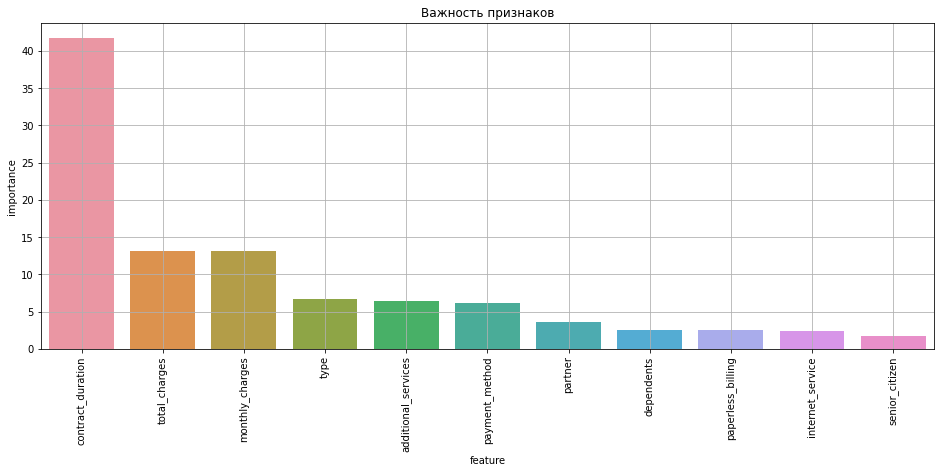

```python
display(fi_df.style.background_gradient('YlGnBu'))

plt.figure(figsize=(16, 6))
sns.barplot(x=fi_df['feature'], y=fi_df['importance'])
plt.title('Важность признаков')
plt.xticks(rotation=90)
plt.grid(True)
plt.show()
```

Наибольшее внимание модели уделяется признаку `'contract_duration'`.

На втором месте по важности стоят признаки `'total_charges'` и `'monthly_charges'`.

В меньшей степени на модель также влияют `'type'`, `'additional_services'` и `'payment_method'`.

Остальные признаки имеют минимальное влияние.

### Вывод

Целевой признак - `'broken_contract'`.

Из входных признаков были удалены:

- `'broken_contract'`,
- `'begin_date'`,
- `'end_date'`,
- `'gender'`,
- `'service_kind'`,
- `'online_security'`,
- `'online_backup'`,
- `'device_protection'`,
- `'tech_support'`,
- `'streaming_tv'`,
- `'streaming_movies'`,
- `'multiple_lines'`.

Данные были разбиты на тренировочные и тестовые выборки в соотношении 75:25. Классы целевого признака между выборками распределены равномерно.

Для подготовки данных мы использовали `StandardScaler` для масштабирования количественных признаков и `OrdinalEncoder` для кодирования категориальных признаков.

В обучениии мы использовали следующие модели:

- `LogisticRegression` с гиперпараметрами `C` и `solver`,
- `RandomForestClassifier` с гиперпараметрами `n_estimators` и `max_depth`,
- `CatBoostClassifier` с гиперпараметрами `depth` и `learning_rate`.

Модели оценивались на кроссвалидации при помощи метрик ROC-AUC и Accuracy.

Результаты обучения и анализа моделей:

- Модели `LogisticRegression` и `RandomForestClassifier` не соответствуют требованиям заказчика по пороговому значению метрик.
- Наилучшие показатели достигла модель `CatBoostClassifier` с гиперпараметрами {`'depth'`: 6, `'learning_rate'`: 0.1}.
- Её метрики на кроссвалидации: ROC-AUC = 0.90, Accuracy = 0.90.
- Её метрики на тестовой выборке: ROC-AUC = 0.92, Accuracy = 0.93.
- ROC-кривая показала очень хорошее качество модели.
- В матрице ошибок количество ложноположительных значений очень низко, но ложноотрицательных значений немало. Модель очень точно предсказывает класс 0, но с классом 1 она ошибается в 39% случаев.
- Сравнение нашей модели с константной моделью показали лучшие результаты по сравнению с простым предсказанием константы.
- Наибольшее внимание модель уделяет признаку `'contract_duration'`. В значительно меньшей степени на модель также влияют `'total_charges'`, `'monthly_charges'` и `'type'`.

Вернуться к содержанию

## Общий вывод

**Рекомендации заказчику**

Оптимизация системы хранения данных, т.к. имеют неоптимальный вид, требуют дополнительной предобработки

Создание механизма для получения обратной связи позволит оперативно реагировать на проблемы и улучшать клиентский опыт.

Проведение опросов среди клиентов, которые разрывают договор, чтобы выяснить причины их ухода. Это поможет оператору выявить слабые места и работать над их устранением.

**Этапы работы**

*Загрузка, предобработка и объединение:*

Всего у нас представлено 7043 записей об абонентах оператора связи, среди которых 5517 (78%) абонентов пользуются (или пользовались ранее) интернет-услугами и 6361 (90%) (или пользовались ранее) пользуются услугами телефонии.

Чтобы выяснить, сколько клиентов отказались от услуг связи, нам необходимо создать новый признак, также дополнительно посчитаем длительность контракта с каждым клиентом.

Данные требовали проведения предобработки:

- привели наименования столбцов к змеиному регистру,
- привели признаки в соответствующий тип данных, исправили некоректные значения,
- объединили исходные датафреймы в один общий,
- заполнили пропуски в признаках доп. услуг,
- удалили дубликаты,
- добавили новые признаки - `'broken_contract'` и`'contract_duration'`, `'service_kind'`, `'additional_services'`.

*Анализ данных:*

Целевой признак сильно не сбалансирован - мы имеем 15.6% клиентов, разорвавших договор. Более двух трети клиентов одновременно используют интернет и телефонию, и именно среди них больше всего ушедших клиентов (17.3%). Мы наблюдаем тенденцию, что от оператора связи уходят давние клиенты спустя 1.5—3.5 года после заключения договора. Много ушедших приходится на тех, кто оплачивал услуги один или два раза в год, платил за услуги более 80 у.е. в месяц и пользовался бóльшим количеством дополнительных услуг. Среди клиентов, подключивших автоплатеж, в 1.5—2 раза больше ушедших клиентов, чем по другим способам оплаты. Клиенты, имеющие супруга, уходят в два раза чаще.

Удаленные признаки:`'begin_date'`, `'end_date'`, `'gender'`, `'service_kind'`, `'online_security'`, `'online_backup'`, `'device_protection'`, `'tech_support'`, `'streaming_tv'`, `'streaming_movies'`, `'multiple_lines'`.

*Обучение моделей:*

Подготовлены данные для обучения моделей. Для обучения мы выбрали 3 модели: `LogisticRegression`, `RandomForestClassifier`, `CatBoostClassifier`. Модели оценивались при помощи метрик ROC-AUC и Accuracy. Лучшая модель: модель `CatBoostClassifier` с гиперпараметрами {`'depth'`: 6, `'learning_rate'`: 0.1}. Метрики модели на тестовой выборке: ROC-AUC = 0.92, Accuracy = 0.93.

Вернуться к содержанию